# Monte Carlo Plausibility Analysis — Other Early Stage Biomass

Published

April 13, 2026

## 1 Objective

This document summarises a Monte Carlo plausibility analysis designed to test whether the Project Design (PD) above-ground biomass (AGB) curve for the **Other Early Stage (High Profile)** species group is directionally consistent with the species-group growth assumptions embedded in the project workbook.

The analysis does **not** validate the PD curve against field data. No empirical observations are used. Instead, it asks a narrower, well-defined question:

> *If we propagate the stated species traits, growth model parameters, and composition uncertainty through the same modelling framework as the PD, does the PD trajectory fall within the resulting plausible range?*

The output is a **plausibility envelope** — a family of simulated AGB trajectories generated by 1,000 Monte Carlo iterations — against which the PD curve is positioned.

## 2 Inputs and Modelling Framework

### 2.1 Species pool

The simulation draws on ten tropical tree species assigned to the Other Early Stage group. Each species is characterised by three inputs read directly from the project workbook.

| Species | H40 target (m) | DBH40 target (cm) | Wood density (g/cm³) |
| --- | --- | --- | --- |
| *Tabebuia rosea* | 30 | 50 | 0.54 |
| *Zygia longifolia* | 15 | 30 | 0.71 |
| *Anacardium excelsum* | 30 | 60 | 0.41 |
| *Gliricidia sepium* | 15 | 30 | 0.53 |
| *Schizolobium parahyba* | 30 | 50 | 0.49 |
| *Cordia alliodora* | 20 | 35 | 0.49 |
| *Inga laurina* | 20 | 45 | 0.62 |
| *Terminalia amazonia* | 30 | 50 | 0.66 |
| *Vochysia guatemalensis* | 25 | 50 | 0.33 |
| *Crescentia cujete* | 10 | 35 | 0.70 |

H40 and DBH40 denote expected height and diameter at breast height at Year 40. These are treated as **Year-40 expected values, not asymptotes** — see Section 3 for discussion.

### 2.2 Growth model

Tree dimensions at any age are modelled with a **target-normalised Chapman–Richards** function:

$$X(t) = X_{40} \times \frac{\left(1 - e^{-k \, t}\right)^{p}}{\left(1 - e^{-k \times 40}\right)^{p}}$$

where $X_{40}$ is the Year-40 target (height or DBH), and $k$ and $p$ are shape parameters sampled independently per species and per simulation. By construction the curve passes through $X_{40}$ exactly at $t = 40$. Parameters are drawn from:

- DBH: $k \sim \mathcal{N}(0.045,\, 0.008)$, $p \sim \mathcal{N}(1.1,\, 0.1)$
- Height: $k \sim \mathcal{N}(0.07,\, 0.01)$, $p \sim \mathcal{N}(1.2,\, 0.1)$

All draws are truncated at 0.001 to prevent physically implausible values.

### 2.3 Allometry

Individual-tree AGB is estimated using the Chave et al. (2014) pantropical allometric equations, applied separately below and above a 10 cm DBH threshold:

- DBH < 10 cm: $\text{AGB} = 0.078479 \times (\rho \cdot D^2 \cdot H)^{0.945339}$
- DBH ≥ 10 cm: $\text{AGB} = 0.0673 \times (\rho \cdot D^2 \cdot H)^{0.976}$

where $\rho$ is wood density (g/cm³), $D$ is DBH (cm), and $H$ is height (m). Both equations return AGB in **kg per tree**; results are converted to Mg by dividing by 1,000. AGB/ha values are in Mg/ha throughout. No carbon fraction is applied — the comparison with the PD is made in AGB units only.

### 2.4 Cohort structure

The PD plants trees in three staggered cohorts (Years 1, 2, and 3). Each cohort has a distinct stand age at any given projection year, and therefore distinct predicted dimensions and AGB per tree. Group-level AGB/ha is the sum of each cohort’s (species-weighted AGB/tree × cohort trees/ha), using the trees-per-hectare schedule read directly from the PD workbook. The PD `PD_AGB_ha_Mg` values are used as-is for comparison — they are not recomputed.

### 2.5 Monte Carlo structure

Each of the 1,000 iterations:

1. Draws a species-composition vector from a Dirichlet distribution (all ten species present; weights vary by scenario — see Section 3).
2. Samples species-level wood density, Year-40 size targets, and growth curve parameters independently for each of the ten species.
3. Grows each species through all three cohorts using the Chapman–Richards model and Chave allometry.
4. Computes a composition-weighted group AGB/tree per cohort, then sums cohort contributions to obtain AGB/ha at each stand year.

The result is a distribution of 1,000 AGB/ha trajectories from which percentile envelopes are derived.

## 3 Key Assumptions

The following inputs are **expert-specified assumptions** drawn from the project workbook or set as explicit modelling choices. None are calibrated from field measurements or fitted to observed data.

| Assumption | Value / Basis |
| --- | --- |
| Year-40 targets | Expected values *at* Year 40; not asymptotes (per workbook label) |
| Species composition | Dirichlet-sampled each iteration; see scenarios below |
| Dirichlet concentration (Scenario A) | alpha = 10 × weight = 1.0 per species — high variability |
| Dirichlet concentration (Scenario B) | alpha = 100 × weight = 10.0 per species — moderate variability |
| Wood density uncertainty | CV = 10% around species mean |
| Size target uncertainty (H40, DBH40) | CV = 10% around species mean |
| Growth curve shape (k, p) | Normal draws with workbook means and SDs |
| Allometry | Chave et al. (2014) pantropical; two-equation form |
| Carbon fraction | Not applied — comparison in AGB, not carbon |
| Empirical calibration | None — internal consistency check only |
| Random seed | 42 (fully reproducible) |

The **Dirichlet concentration** is the single assumption with no workbook basis. It controls how variable species composition is across iterations. Higher values concentrate weight near equal proportions; lower values allow extreme single- species dominance. Two scenarios are tested explicitly to bound this uncertainty.

## 4 Results

### 4.1 Primary scenario: Scenario B (alpha_concentration = 100)

Scenario B is the primary reporting scenario. It assumes moderate composition variability, consistent with a mixed-species planting in which all ten species are present in broadly comparable proportions. Under this scenario, trait and parameter uncertainty accounts for approximately 80% of simulated variance; the remaining 20% reflects residual composition variability.

Table 1: Scenario B (alpha=100) — simulated AGB/ha percentile envelope and PD position at milestone years. All values in Mg/ha.

| Year | P10 (Mg/ha) | P50 (Mg/ha) | P90 (Mg/ha) | P100 (Mg/ha) | PD (Mg/ha) | PD Percentile | Within P10–P90 |
| --- | --- | --- | --- | --- | --- | --- | --- |
| 10 | 17.4 | 21.1 | 25.7 | 34.0 | 20.7 | 45.5 | Yes |
| 20 | 92.4 | 107.6 | 126.5 | 159.5 | 103.6 | 36.7 | Yes |
| 30 | 176.1 | 203.5 | 236.6 | 284.5 | 189.6 | 24.9 | Yes |
| 40 | 231.3 | 265.3 | 306.2 | 362.9 | 239.1 | 16.2 | Yes |

The PD AGB curve falls within the P10–P90 plausibility band in every year of the 40-year projection. At Year 40, the PD value of 239 Mg/ha sits at approximately the **16th percentile** of the simulated distribution (P10 = 231 Mg/ha, P50 = 265 Mg/ha, P90 = 306 Mg/ha). The PD curve does not exceed the simulation maximum (P100) at any point.

The PD tends toward the **lower portion of the plausible range**. This reflects the fact that the equal-weight species mixture, centred on ten species with varying productivity, produces a group mean that somewhat exceeds the PD trajectory. This is consistent with a PD design that draws on a subset of the species group or applies conservative growth assumptions, though the exact species composition assumed in the PD is not reconstructed here.

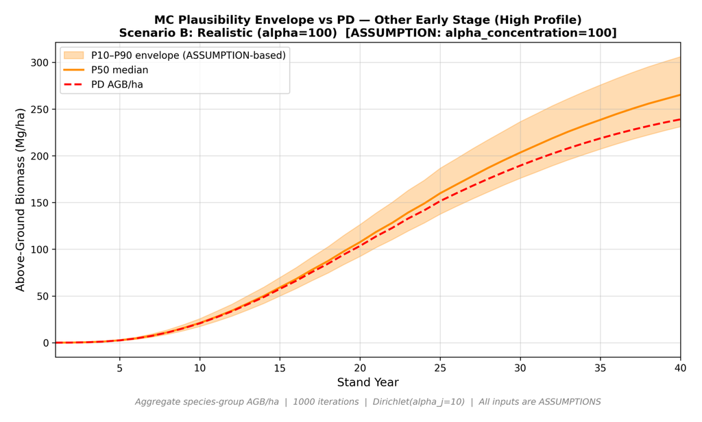

Figure 1: Monte Carlo plausibility envelope (Scenario B, alpha=100) versus the PD AGB/ha trajectory. Shaded band: P10–P90 range across 1,000 simulations. Solid line: median (P50). Dashed red line: PD AGB/ha. All values in Mg/ha. Inputs are expert-specified assumptions — not empirically calibrated.

## 5 Sensitivity and Robustness

Two composition scenarios were tested to assess how sensitive the results are to the Dirichlet concentration assumption.

Table 2: Scenario comparison at milestone years — envelope width (P10–P90 range) and PD percentile position. All AGB values in Mg/ha.

| Year | P10–P90 width, Scenario A (Mg/ha) | P10–P90 width, Scenario B (Mg/ha) | PD percentile, Scenario A | PD percentile, Scenario B |
| --- | --- | --- | --- | --- |
| 10 | 12.9 | 8.3 | 50.6 | 45.5 |
| 20 | 59.7 | 34.1 | 44.7 | 36.7 |
| 30 | 110.2 | 60.5 | 38.5 | 24.9 |
| 40 | 144.0 | 74.9 | 32.9 | 16.2 |

**Envelope width.** The P10–P90 band at Year 40 narrows from 144 Mg/ha (Scenario A) to 75 Mg/ha (Scenario B) — approximately a 48% reduction. This narrowing is driven by the shift in what dominates simulated variance: under Scenario A, roughly 59% of variance at Year 40 is attributable to the composition draw; under Scenario B, only 20% is, with the remaining 80% from wood density, size target, and growth curve shape uncertainty. Scenario A should be read as a stress test that probes the outer envelope of composition uncertainty; it is not a more realistic representation of planting variability.

**Qualitative conclusion.** The finding that the PD trajectory is directionally consistent with the species-group assumptions holds under both scenarios. The PD remains within the P10–P90 band for all 40 years and never exceeds P100 in either scenario. The conclusion is not sensitive to the composition choice; what changes is the PD’s position within the envelope, not whether it is within it.

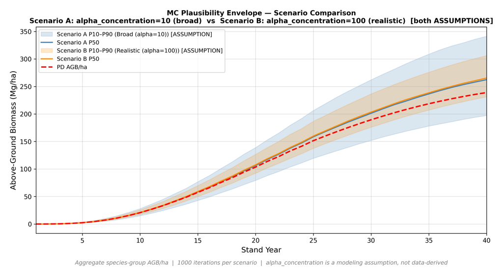

Figure 2: Side-by-side comparison of the Scenario A (blue, broad) and Scenario B (orange, realistic) plausibility envelopes. Shaded regions: P10–P90. Lines: P50 medians. Dashed red: PD AGB/ha. The narrower Scenario B envelope is the primary reference for diligence purposes.

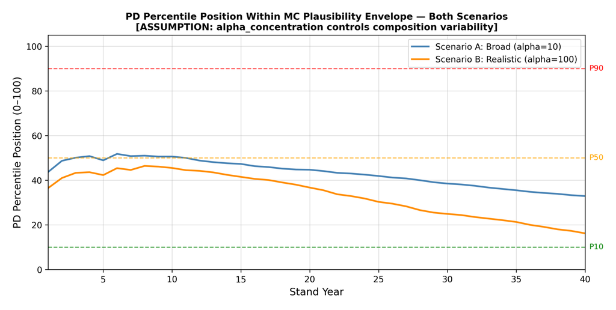

Figure 3: PD percentile position within the simulated envelope across the 40-year projection period, for both composition scenarios. A position below the 50th percentile indicates the PD trajectory falls in the lower half of the plausible range. Dashed reference lines at the 10th, 50th, and 90th percentiles.

## 6 Interpretation for Diligence

Several points are important for interpreting these results in a diligence context.

**The PD trajectory is directionally plausible.** It falls within the P10–P90 range of the simulated species-group envelope throughout the full projection period under both tested scenarios. This is consistent with a PD growth curve that reflects assumptions within the range of what the modelled species group could plausibly achieve.

**The PD sits toward the lower percentiles under the primary scenario.** At Year 40, the PD value of 239 Mg/ha is below the group median of 265 Mg/ha under Scenario B. This gap grows over time: the PD percentile position declines from around the 45th percentile at Year 10 to the 16th at Year 40. The most likely explanation is that the equal-weight species mixture includes several high-productivity species (notably *Anacardium excelsum* with DBH40 = 60 cm) that lift the group mean above the PD trajectory. Whether this implies the PD is conservative depends on the intended species composition, which is not reconstructed in this analysis.

**The envelope width is assumption-dependent.** Under Scenario B, the width is driven by biologically grounded uncertainty (wood density, size targets, growth curve shape). Under Scenario A, composition variability dominates and the envelope is substantially wider. Scenario B is the appropriate reference for diligence discussions; Scenario A provides a useful outer bound but should not be cited as the primary result.

**Directional consistency does not imply adequacy.** Falling within the plausibility envelope confirms that the PD curve is not inconsistent with the modelled assumptions. It does not confirm that the underlying assumptions themselves are correct, that the species composition is representative, or that growth targets will be realised in the field.

## 7 Limitations

The following limitations apply and should be explicitly acknowledged in any downstream use of this analysis.

1. **No empirical validation.** The simulation uses no field measurements, observational growth data, or independently calibrated parameters. All species traits, growth curve parameters, and composition weights are expert-specified inputs. The analysis tests internal model consistency, not real-world accuracy.
2. **Shared growth parameters across species.** The Chapman–Richards shape parameters $k$ and $p$ are drawn from a single shared distribution applied to all ten species. In practice, growth timing parameters differ systematically across species; using species-specific parameter distributions (where literature data exist) would produce a more differentiated envelope.
3. **Composition prior is a modelling assumption.** The Dirichlet concentration parameter has no empirical basis. The choice of alpha_concentration = 100 for Scenario B is reasonable for a mixed-species planting but is not derived from observed plot composition data. The sensitivity analysis (Section 5) bounds the effect of this choice.
4. **Target vs. asymptote interpretation.** H40 and DBH40 are treated as expected values at Year 40 per the workbook label. Under the alternative interpretation — where these are asymptotic maxima approached but not reached by Year 40 — the simulated envelope would be lower, and the PD could move toward or above the upper range. This sensitivity has not been run.
5. **Simulation precision near extremes.** With 1,000 iterations, estimates near the P90 boundary are reasonably stable; the P100 value (single maximum) should be treated as indicative, not as a stable upper bound.

## 8 Conclusion

The Monte Carlo analysis produces a plausibility envelope for the aggregate Other Early Stage species group by propagating uncertainty in species traits, growth curve parameters, and species composition through a target-normalised Chapman–Richards growth model and Chave allometry. Across 1,000 simulations, the PD AGB/ha trajectory falls within the P10–P90 band for all 40 years of the projection and never exceeds the simulation maximum, under both a broad (Scenario A) and a moderate (Scenario B) composition uncertainty assumption. Under the primary Scenario B, the PD reaches the 16th percentile at Year 40, below the group median of 265 Mg/ha, indicating the PD trajectory tends toward the lower portion of the plausible range. The qualitative finding — that the PD curve is directionally consistent with the species-group assumptions — is robust to the composition uncertainty choice. Results are sensitive to the target interpretation assumption and the absence of species-specific growth parameters, both of which are noted as priorities for any follow-on sensitivity work.